# Data Analysis Project: Find the Area to Invest

Xueqing Xie

# Introduction

**Goal:**

A real estate company has a niche in purchasing properties with two-bedroom to rent out short-term as part of their business model specifically within New York City. They want to have a data product with a rational conclusion to help them find out what are the zip codes that will generate the most profit on short term rentals within New York City.

**Datasets:**

Cost data: Zillow provides us an estimation of value for two-bedroom properties

Revenue data: AirBnB is the medium through which the investor plans to lease out their investment property.

**Basic Assumptions:**

The investor will pay for the property in cash (i.e. no mortgage/interest rate will need to be accounted for).

The time value of money discount rate is 0% (i.e. $1 today is worth the same 100 years from now).

All properties and all square feet within each locale can be assumed to be homogeneous (i.e. a 1000 square foot property in a locale such as Bronx or Manhattan generates twice the revenue and costs twice as much as any other 500 square foot property within that same locale.)

**Additional Assumption:**

1. Rent is the only revenue for the property; cost contains the property purchasing cost and the operating expenses.
2. Operating expenses are 50% of revenue (salary, marketing, devices…) and the occupancy rate is 75%.
3. The properties are available throughout a year (365 days).
4. The investor will not sell the property in the period we investigate.
5. The rental price keeps constant in the period we investigate (from 2017 to 2019+).
6. The company has adequate cash to purchase ideal properties.
7. The investment will happen in 2017.
8. The property type makes no difference.

**The whole process will be:**

**Data Overview**: know the size of data, the basic variables and their relationship.

**Data Quality Check**: check the fraud data, missing value, inconsistent data format, outliers, etc.

**Data Cleaning** : Solve the problem found in data quality check and clean the data.

**Data Analysis** : Create new features helpful to analyze the problem, visualize data, make conclusion and recommendation and think about the future work to improve the current work.

==================================================================================================================

## Data Overview

### **Loading Packages & Datasets**

```r
#Load Packages
library(flexdashboard)  #For dashboard generation
library(dplyr)  #For data cleaning
library(leaflet)  #For data mapping
library(stringr)  #For dealing with string datatype
library(ggplot2)  #For data visualiztion
library(psych)
library(kableExtra)   #For neat table
```

```r
#Import dataset
zillow <-
  read.csv("Zip_Zhvi_2bedroom.csv",
  header = TRUE,
  na.strings = "")

airbnb <- read.csv("listings.csv", header=TRUE, na.strings = "")
```

==================================================================================================================

### **Airbnb Dataset**

```r
#Dimension
dim(airbnb)
```

```
## [1] 48895   106
```

```r
#Overview on neighbourhood
airbnb %>%
  group_by(neighbourhood_group_cleansed) %>%
  summarise(unique_zipcodes = n_distinct(zipcode),
            number_properties = n())
```

```
## # A tibble: 5 x 3
##   neighbourhood_group_cleansed unique_zipcodes number_properties
##   <fct>                                  <int>             <int>
## 1 Bronx                                     29              1091
## 2 Brooklyn                                  50             20104
## 3 Manhattan                                 61             21661
## 4 Queens                                    72              5666
## 5 Staten Island                             13               373
```

**Airbnb Dataset: 48895 rows and 106 columns.**  
**Brooklyn and Manhattan have much more properties than Bronx, Quees, and Staten Island.**

```r
#Overview on Dataset

kable(head(airbnb[c(
  "neighbourhood_group_cleansed",
  "zipcode",
  "calendar_updated",
  "room_type",
  "host_verifications",
  "bedrooms",
  "price",
  "weekly_price",
  "cleaning_fee",
  "number_of_reviews"
  )])) %>%
  kable_styling(bootstrap_options = c("striped", "hover", "condensed", "responsive"))
```

| neighbourhood_group_cleansed | zipcode | calendar_updated | room_type | host_verifications | bedrooms | price | weekly_price | cleaning_fee | number_of_reviews |
| --- | --- | --- | --- | --- | --- | --- | --- | --- | --- |
| Brooklyn | 11218 | 3 weeks ago | Private room | [‘email’, ‘phone’, ‘reviews’, ‘kba’] | 1 | $149.00 | $299.00 | $25.00 | 9 |
| Manhattan | 10018 | 4 days ago | Entire home/apt | [‘email’, ‘phone’, ‘reviews’, ‘kba’, ‘work_email’] | 0 | $225.00 | $1,995.00 | $100.00 | 45 |
| Manhattan | 10027 | 34 months ago | Private room | [‘email’, ‘phone’, ‘google’, ‘reviews’, ‘jumio’, ‘government_id’] | 1 | $150.00 | NA | $75.00 | 0 |
| Brooklyn | 11238 | today | Entire home/apt | [‘email’, ‘phone’, ‘reviews’, ‘kba’] | 1 | $89.00 | $575.00 | NA | 270 |
| Manhattan | 10029 | 3 months ago | Entire home/apt | [‘email’, ‘phone’, ‘facebook’, ‘reviews’, ‘kba’] | NA | $80.00 | $600.00 | $80.00 | 9 |
| Manhattan | 10016 | 3 weeks ago | Entire home/apt | [‘email’, ‘phone’, ‘reviews’, ‘jumio’, ‘government_id’] | 1 | $200.00 | NA | $125.00 | 74 |

==================================================================================================================

### **Zillow Dataset**

```r
#Dimension
dim(zillow)
```

```
## [1] 8946  262
```

```r
#Overview on city and region
zillow %>%
  summarise(unique_cities = n_distinct(City),
  unique_zipcodes = n_distinct(RegionName))
```

```
##   unique_cities unique_zipcodes
## 1          4684            8946
```

**Zillow Dataset: 8946 rows and 262 columns.**  
**Zillow data cover 4684 cities while we only need New York City data.**

```r
#Dataset
kable(head(zillow[, 1:15])) %>%
  kable_styling(bootstrap_options = c("striped", "hover", "condensed", "responsive"))
```

| RegionID | RegionName | City | State | Metro | CountyName | SizeRank | X1996.04 | X1996.05 | X1996.06 | X1996.07 | X1996.08 | X1996.09 | X1996.10 | X1996.11 |
| --- | --- | --- | --- | --- | --- | --- | --- | --- | --- | --- | --- | --- | --- | --- |
| 61639 | 10025 | New York | NY | New York | New York | 1 | NA | NA | NA | NA | NA | NA | NA | NA |
| 84654 | 60657 | Chicago | IL | Chicago | Cook | 2 | 167700 | 166400 | 166700 | 167200 | 166900 | 166900 | 168000 | 170100 |
| 61637 | 10023 | New York | NY | New York | New York | 3 | NA | NA | NA | NA | NA | NA | NA | NA |
| 84616 | 60614 | Chicago | IL | Chicago | Cook | 4 | 195800 | 193500 | 192600 | 192300 | 192600 | 193600 | 195500 | 197600 |
| 93144 | 79936 | El Paso | TX | El Paso | El Paso | 5 | 59100 | 60500 | 60900 | 60800 | 60300 | 60400 | 61200 | 61700 |
| 84640 | 60640 | Chicago | IL | Chicago | Cook | 6 | 123300 | 122600 | 122000 | 121500 | 120900 | 120600 | 120900 | 121300 |

==================================================================================================================

## Data Quality

### **Airbnb Dataset**

#### **Missing Value**

```r
#Select important features of 2-bedrooms property in Airbnb dataset
airbnb2 <-
  airbnb[c(
  "neighbourhood_group_cleansed",
  "zipcode",
  "country_code",
  "latitude",
  "longitude",
  "is_location_exact",
  "bedrooms",
  "price",
  "weekly_price",
  "monthly_price",
  "number_of_reviews"
  )] %>% filter(bedrooms == 2)
#with 4892 rows

#Check missing value for important features in Airbnb dataset
missing_airbnb <-
  as.data.frame(sapply(airbnb2, function(x)
  sum(is.na (x)) / nrow(airbnb2)))
  names(missing_airbnb)[1] <- "missing"
  missing_airbnb
```

```
##                                 missing
## neighbourhood_group_cleansed 0.00000000
## zipcode                      0.00769586
## country_code                 0.00000000
## latitude                     0.00000000
## longitude                    0.00000000
## is_location_exact            0.00000000
## bedrooms                     0.00000000
## price                        0.00000000
## weekly_price                 0.87840542
## monthly_price                0.89287363
## number_of_reviews            0.00000000
```

```r
#Weekly_price, monthly_price both have more than 70% missing values, so we do drop these two features
  airbnb2 <-
    airbnb2[, !colnames(airbnb2) %in% c("weekly_price", "monthly_price")]
```

**For price data we only take daily price of properties because the percentage of missing values in weekly_price and monthly_price are too high, over 80%.**

**We find zipcode has a small part of missing values and we will deal with these missing value later.**

#### **Outlier**

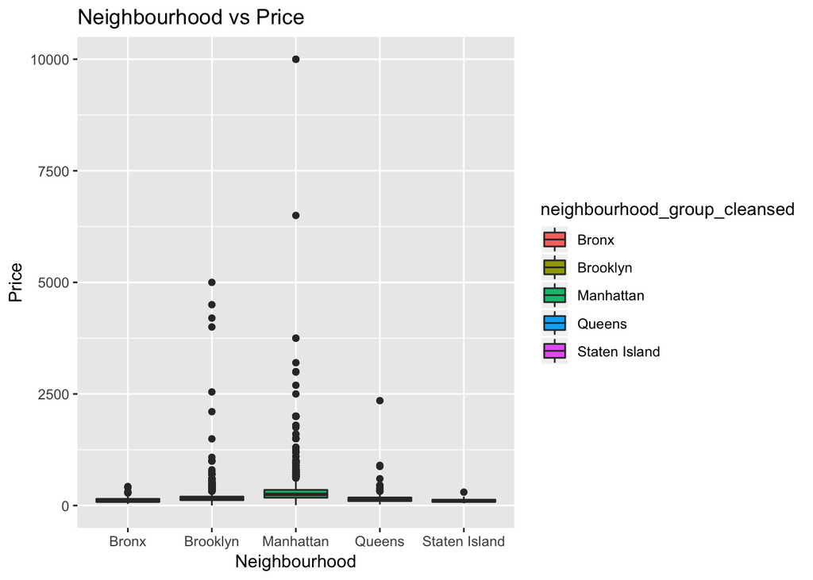

```r
airbnb2 %>% mutate(price = as.numeric(gsub(",", "", (
  gsub("\\$", "", price)
  )))) %>%
  ggplot(aes(x = neighbourhood_group_cleansed, y = price, fill =
  neighbourhood_group_cleansed)) +
  geom_boxplot() +
  labs(title = "Neighbourhood vs Price", x = "Neighbourhood",
  y = "Price")
```

**It is obvious that some points in Brooklyn and Manhattan price data are outliers. Therefore, we need to deal with outliers later.**

==================================================================================================================

### **Zillow Dataset**

#### **Missing Value**

```r
#Select important features in Zillow dataset
zillow2 <-
  subset(zillow[, c(2, 3, 7, ncol(zillow) - 2, ncol(zillow) - 1, ncol(zillow))], zillow$City ==
  "New York")

#Check missing value for important features in Zillow dataset
missing_zillow <-
  as.data.frame(sapply(zillow2, function(x)
  sum(is.na (x)) / nrow(zillow2)))
  names(missing_zillow)[1] <- "missing"
  missing_zillow
```

```
##            missing
## RegionName       0
## City             0
## SizeRank         0
## X2017.04         0
## X2017.05         0
## X2017.06         0
```

**Here we only select the latest three months purchasing price because if it is the latest time period in zillow dataset and closest to the time of airbnb data. Getting an average of latest three month prices reduces monthly variation in house price. The data we get from zillow is neat and the features we need have no missing values.**

==================================================================================================================

## Data Cleaning

### **Summary of data cleaning**

#### **(1) Airbnb Dataset:**

**Zipcode:**  
Filter zipcodes with 5 digits  
Remove missing value

**Price:**  
Remove dollar sign and comma in price Change the data type to numeric type

**Others:**  
Filter “is_location_exact” which is true  
Remove outliers in every borough

#### **(2) Zillow Dataset:**

**Zipcode:**  
Filter zipcodes with 5 digits  
Rename the column name from RegionName to zipcode  
Filter the zipcode in New York

**Price:**  
Make sure no missing value  
Use the mean of lastest three month as purchasing price

==================================================================================================================

### **Airbnb Dataset**

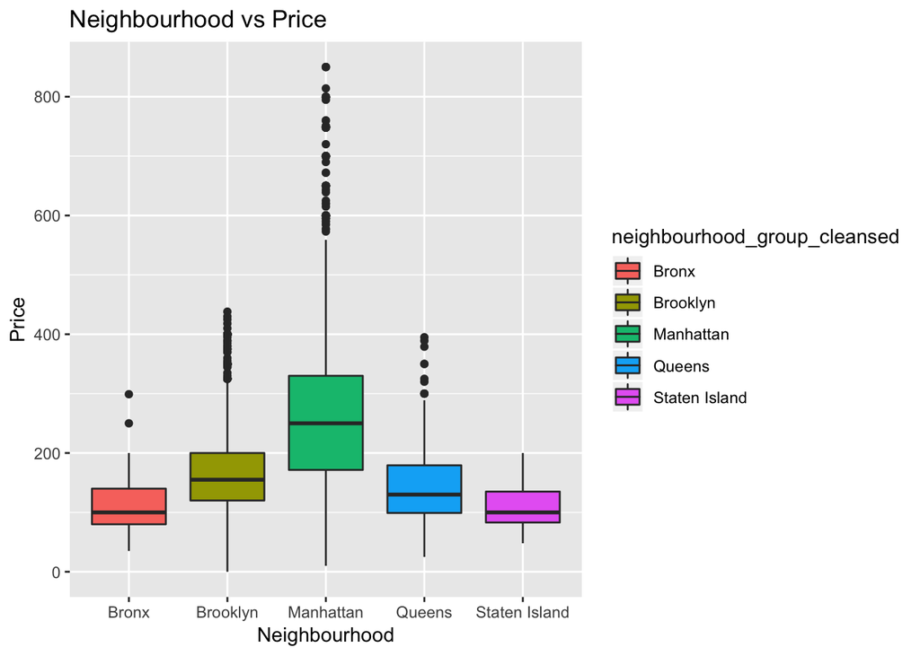

```r
#Outlier function (extreme outliers)
is_outlier <- function(x) {
  return(x < quantile(x, 0.25) - 3 * IQR(x) |
  x > quantile(x, 0.75) + 3 * IQR(x))
}

#Clean data (data type, filter, remove outliers)
airbnb_final <- airbnb2 %>%
  mutate(price = as.numeric(gsub(",", "", (
  gsub("\\$", "", price)
  )))) %>%
  filter(is_location_exact == "t" &
  !is.na(zipcode) & (str_length(zipcode)) == 5) %>%
  group_by(neighbourhood_group_cleansed) %>%
  mutate(outlier = is_outlier(price)) %>%
  filter(outlier == FALSE) %>%
  select(c(1, 2, 4, 5, 8, 9))

airbnb_final %>% ggplot(aes(x = neighbourhood_group_cleansed, y = price, fill =
                              neighbourhood_group_cleansed)) +
                              geom_boxplot() +
                              labs(title = "Neighbourhood vs Price", x = "Neighbourhood",
                              y = "Price")
```

```r
kable(head(airbnb_final)) %>%
  kable_styling(bootstrap_options = c("striped", "hover", "condensed", "responsive"))
```

| neighbourhood_group_cleansed | zipcode | latitude | longitude | price | number_of_reviews |
| --- | --- | --- | --- | --- | --- |
| Manhattan | 10029 | 40.79685 | -73.94872 | 190 | 0 |
| Brooklyn | 11221 | 40.68554 | -73.94090 | 115 | 11 |
| Brooklyn | 11206 | 40.70420 | -73.93560 | 228 | 82 |
| Manhattan | 10001 | 40.74623 | -73.99530 | 375 | 5 |
| Manhattan | 10162 | 40.77065 | -73.95269 | 250 | 66 |
| Brooklyn | 11215 | 40.67343 | -73.98338 | 225 | 4 |

==================================================================================================================

### **Zillow Dataset**

```r
#Clean data (rename, )
zillow_final <- zillow2 %>%
  rename(zipcode = RegionName) %>%
  mutate(purchase_price = (X2017.05 + X2017.04 + X2017.06) / 3) %>%
  filter(!is.na(zipcode) & (str_length(zipcode)) == 5) %>%
  select(c(1, 2, 3, 7))

kable(head(zillow_final)) %>%
  kable_styling(bootstrap_options = c("striped", "hover", "condensed", "responsive"))
```

| zipcode | City | SizeRank | purchase_price |
| --- | --- | --- | --- |
| 10025 | New York | 1 | 1391033 |
| 10023 | New York | 3 | 2086567 |
| 10128 | New York | 14 | 1717900 |
| 10011 | New York | 15 | 2422000 |
| 10003 | New York | 21 | 2100467 |
| 11201 | New York | 32 | 1409500 |

==================================================================================================================

### **Merge Two Datasets**

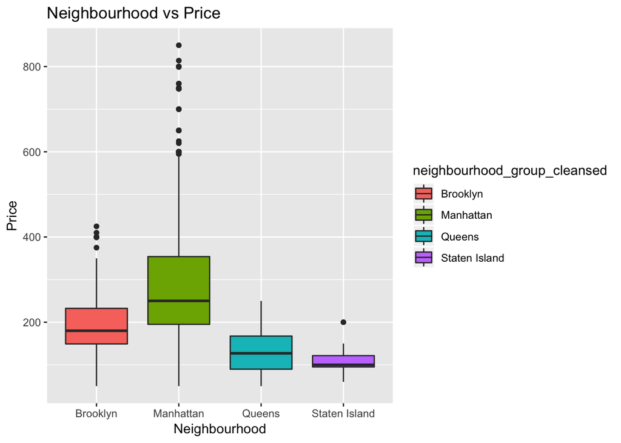

```r
data <- merge(x = airbnb_final, y = zillow_final, by = "zipcode")

data %>% ggplot(aes(x = neighbourhood_group_cleansed, y = price, fill = neighbourhood_group_cleansed)) +
  geom_boxplot() +
  labs(title = "Neighbourhood vs Price", x = "Neighbourhood",
  y = "Price")
```

```r
kable(head(data)) %>%
  kable_styling(bootstrap_options = c("striped", "hover", "condensed", "responsive"))
```

| zipcode | neighbourhood_group_cleansed | latitude | longitude | price | number_of_reviews | City | SizeRank | purchase_price |
| --- | --- | --- | --- | --- | --- | --- | --- | --- |
| 10003 | Manhattan | 40.72577 | -73.98745 | 249 | 166 | New York | 21 | 2100467 |
| 10003 | Manhattan | 40.73502 | -73.98612 | 280 | 0 | New York | 21 | 2100467 |
| 10003 | Manhattan | 40.73125 | -73.98675 | 480 | 2 | New York | 21 | 2100467 |
| 10003 | Manhattan | 40.72569 | -73.99227 | 455 | 93 | New York | 21 | 2100467 |
| 10003 | Manhattan | 40.72603 | -73.98751 | 151 | 214 | New York | 21 | 2100467 |
| 10003 | Manhattan | 40.72571 | -73.98789 | 250 | 8 | New York | 21 | 2100467 |

==================================================================================================================

## Data Analysis

### **Distribution**

**From the map, we see most of properties are distributed in Manhattan. The density of properties in Manhattan is much higher than other neighbourhoods.**

```r
myPopup <- paste(
  sep = '<br/>',
  paste('<b>Zipcode</b>:', data$zipcode),
  paste('<b>Neighborhood</b>:', data$neighbourhood_group_cleansed),
  paste('<b>Rent price</b>:', data$price),
  paste('<b>Purchase price</b>:', format(round(
  data$purchase_price, 2
  ), nsmall = 2)),
  paste('<b>Population</b>:', data$SizeRank)
  )

leaflet(width = 900, height = 600) %>% addTiles() %>% addMarkers(
  data = data,
  lng = ~ longitude,
  lat = ~ latitude,
  popup = myPopup ,
  clusterOptions = markerClusterOptions(),
  icon = list(iconUrl = 'http://icons.iconarchive.com/icons/graphicloads/colorful-long-shadow/256/Home-icon.png', iconSize = c(20, 20))
  )
```

[interactive chart not shown]

==================================================================================================================

### **New Feature**

#### **Fomula**

$$Expected Revenue/year= DailyRent * Days/year* Occupancy Rate$$

$$Return On Investment= (ExpectedRevenue/year-OperatingExpense/year)/TotalCost$$

$$BreakEvenPeriod=TotalCost/(ExpectedRevenue/year-OperatingExpense/year))$$

#### **Create new features**

**After creating new features and grouping data by zipcode, we finally keep 24 zipcodes in our dataset to do final analysis.**

```r
data2 <- data %>%
  group_by(zipcode) %>%
  summarise(
  mean_rent_price = mean(price),
  mean_reviews = mean(number_of_reviews),
  purchase_price = mean(purchase_price),
  neighbourhood = first(neighbourhood_group_cleansed),
  SizeRank = first(SizeRank),
  City = first(City)
  ) %>%
  mutate(
  occupancy_rate = 0.75,
  revenue_y01 = mean_rent_price * 365 * 0.75,
  return_rate = (revenue_y01 - 0.5 * revenue_y01) / purchase_price,
  break_even = purchase_price / (revenue_y01 - 0.5 * revenue_y01),
  country = "US"
  )

kable(data2) %>%
  kable_styling(bootstrap_options = c("striped", "hover", "condensed", "responsive"))
```

| zipcode | mean_rent_price | mean_reviews | purchase_price | neighbourhood | SizeRank | City | occupancy_rate | revenue_y01 | return_rate | break_even | country |
| --- | --- | --- | --- | --- | --- | --- | --- | --- | --- | --- | --- |
| 10003 | 276.46667 | 23.166667 | 2100466.7 | Manhattan | 21 | New York | 0.75 | 75682.75 | 0.0180157 | 55.50714 | US |
| 10011 | 344.03125 | 18.729167 | 2422000.0 | Manhattan | 15 | New York | 0.75 | 94178.55 | 0.0194423 | 51.43421 | US |
| 10013 | 335.71250 | 20.387500 | 3257400.0 | Manhattan | 1744 | New York | 0.75 | 91901.30 | 0.0141065 | 70.88910 | US |
| 10014 | 304.65000 | 18.675000 | 2494966.7 | Manhattan | 379 | New York | 0.75 | 83397.94 | 0.0167132 | 59.83281 | US |
| 10021 | 200.65217 | 16.695652 | 1773700.0 | Manhattan | 190 | New York | 0.75 | 54928.53 | 0.0154842 | 64.58210 | US |
| 10022 | 282.98000 | 14.200000 | 1981333.3 | Manhattan | 894 | New York | 0.75 | 77465.77 | 0.0195489 | 51.15377 | US |
| 10023 | 270.03226 | 9.419355 | 2086566.7 | Manhattan | 3 | New York | 0.75 | 73921.33 | 0.0177136 | 56.45371 | US |
| 10025 | 240.47059 | 15.137255 | 1391033.3 | Manhattan | 1 | New York | 0.75 | 65828.82 | 0.0236618 | 42.26214 | US |
| 10028 | 273.93939 | 4.787879 | 2007466.7 | Manhattan | 109 | New York | 0.75 | 74990.91 | 0.0186780 | 53.53893 | US |
| 10036 | 313.84298 | 17.504132 | 1721833.3 | Manhattan | 580 | New York | 0.75 | 85914.51 | 0.0249486 | 40.08248 | US |
| 10128 | 226.35417 | 11.125000 | 1717900.0 | Manhattan | 14 | New York | 0.75 | 61964.45 | 0.0180349 | 55.44792 | US |
| 10303 | 95.33333 | 21.333333 | 321733.3 | Staten Island | 4647 | New York | 0.75 | 26097.50 | 0.0405577 | 24.65626 | US |
| 10304 | 93.33333 | 31.666667 | 321133.3 | Staten Island | 1958 | New York | 0.75 | 25550.00 | 0.0397810 | 25.13764 | US |
| 10305 | 119.40000 | 28.900000 | 418666.7 | Staten Island | 2087 | New York | 0.75 | 32685.75 | 0.0390355 | 25.61769 | US |
| 10306 | 117.50000 | 10.500000 | 348066.7 | Staten Island | 668 | New York | 0.75 | 32165.62 | 0.0462061 | 21.64215 | US |
| 10308 | 109.50000 | 43.000000 | 402933.3 | Staten Island | 4149 | New York | 0.75 | 29975.62 | 0.0371968 | 26.88407 | US |
| 10309 | 85.00000 | 8.000000 | 383800.0 | Staten Island | 3682 | New York | 0.75 | 23268.75 | 0.0303136 | 32.98845 | US |
| 10314 | 68.00000 | 11.000000 | 352466.7 | Staten Island | 68 | New York | 0.75 | 18615.00 | 0.0264068 | 37.86910 | US |
| 11201 | 221.54054 | 19.635135 | 1409500.0 | Brooklyn | 32 | New York | 0.75 | 60646.72 | 0.0215136 | 46.48231 | US |
| 11215 | 174.82317 | 30.317073 | 1062333.3 | Brooklyn | 71 | New York | 0.75 | 47857.84 | 0.0225249 | 44.39537 | US |
| 11217 | 201.16514 | 23.238532 | 1272266.7 | Brooklyn | 1555 | New York | 0.75 | 55068.96 | 0.0216421 | 46.20631 | US |
| 11231 | 187.56250 | 28.512500 | 1209266.7 | Brooklyn | 1817 | New York | 0.75 | 51345.23 | 0.0212299 | 47.10337 | US |
| 11234 | 144.85714 | 37.857143 | 476566.7 | Brooklyn | 52 | New York | 0.75 | 39654.64 | 0.0416045 | 24.03586 | US |
| 11434 | 136.87500 | 37.125000 | 379866.7 | Queens | 622 | New York | 0.75 | 37469.53 | 0.0493193 | 20.27603 | US |

==================================================================================================================

### **Data Visualization**

#### **Breakeven**

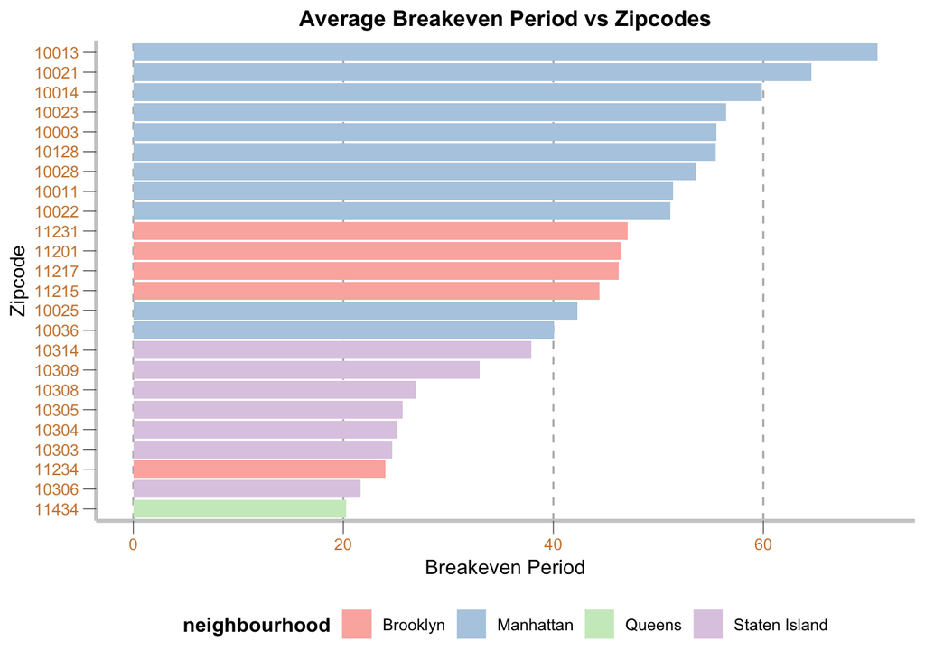

```r
breakeven <- data2 %>%
  ggplot(aes(
  x = reorder(zipcode, break_even),
  y = break_even,
  fill = neighbourhood
  )) +
  geom_bar(stat = "identity") +
  scale_fill_brewer(palette = "Pastel1") +
  labs(title = "Average Breakeven Period vs Zipcodes", x = "Zipcode", y = "Breakeven Period") +
  theme(
  plot.title = element_text(size = 12, face = "bold", hjust = 0.5),
  legend.position = "bottom",
  legend.title = element_text(face = "bold"),
  panel.background = element_rect(fill = "white", colour = "white"),
  panel.grid.major = element_line(colour = "grey70", linetype = "dashed"),
  panel.grid.major.y = element_blank(),
  axis.line = element_line(size = 1, colour = "grey80"),
  axis.text = element_text(colour = "peru"),
  axis.ticks.length = unit(0.25, "cm"),
  axis.ticks = element_line(size = 0.2)
  ) +
  coord_flip()

breakeven
```

#### **Return on investment**

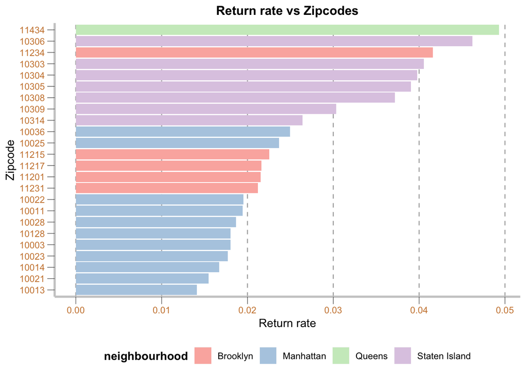

```r
data2$zipcode <-
  factor(data2$zipcode, levels = data2$zipcode[order(data2$return_rate)])
  returnrate <-
  ggplot(data = data2, aes(x = zipcode, y = return_rate, fill = neighbourhood)) +
  geom_histogram(stat = "identity") +
  scale_fill_brewer(palette = "Pastel1") +
  labs(title = "Return rate vs Zipcodes", x = "Zipcode", y = "Return rate") +
  theme(
  plot.title = element_text(size = 12, face = "bold", hjust = 0.5),
  legend.position = "bottom",
  legend.title = element_text(face = "bold"),
  panel.background = element_rect(fill = "white", colour = "white"),
  panel.grid.major = element_line(colour = "grey70", linetype = "dashed"),
  panel.grid.major.y = element_blank(),
  axis.line = element_line(size = 1, colour = "grey80"),
  axis.text = element_text(colour = "peru"),
  axis.ticks.length = unit(0.25, "cm"),
  axis.ticks = element_line(size = 0.2)
  ) +
  coord_flip()

returnrate
```

#### **Cash liquidity**

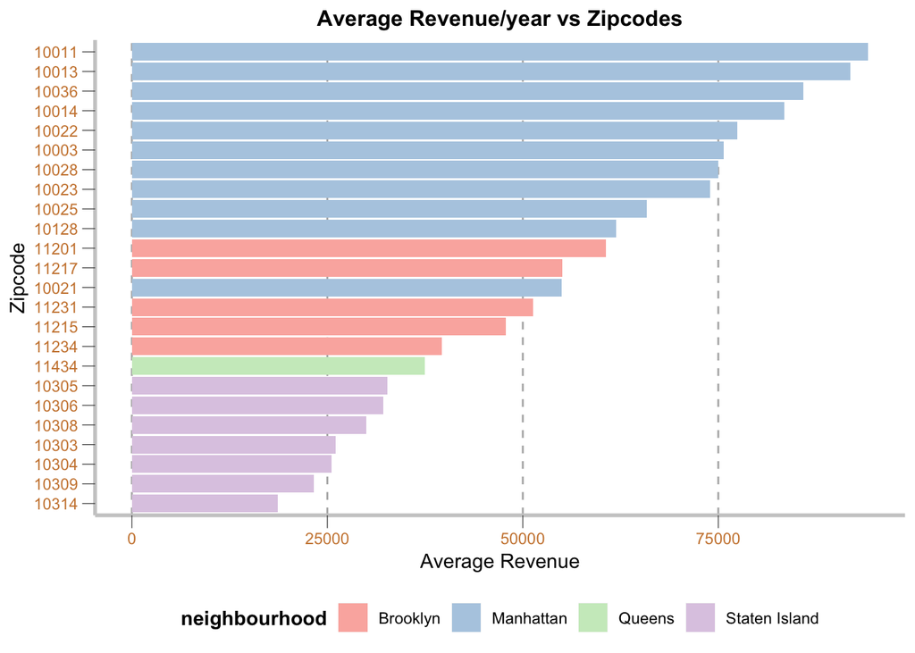

```r
data2$zipcode <-
  factor(data2$zipcode, levels = data2$zipcode[order(data2$revenue_y01)])

revenue_year <-
  ggplot(data = data2, aes(x = zipcode, y = revenue_y01, fill = neighbourhood)) +
  geom_histogram(stat = "identity") +
  scale_fill_brewer(palette = "Pastel1") +
  labs(title = "Average Revenue/year vs Zipcodes", x = "Zipcode", y = "Average Revenue") +
  theme(
  plot.title = element_text(size = 12, face = "bold", hjust = 0.5),
  legend.position = "bottom",
  legend.title = element_text(face = "bold"),
  panel.background = element_rect(fill = "white", colour = "white"),
  panel.grid.major = element_line(colour = "grey70", linetype = "dashed"),
  panel.grid.major.y = element_blank(),
  axis.line = element_line(size = 1, colour = "grey80"),
  axis.text = element_text(colour = "peru"),
  axis.ticks.length = unit(0.25, "cm"),
  axis.ticks = element_line(size = 0.2)
  ) +
  coord_flip()

revenue_year
```

#### **Population scale**

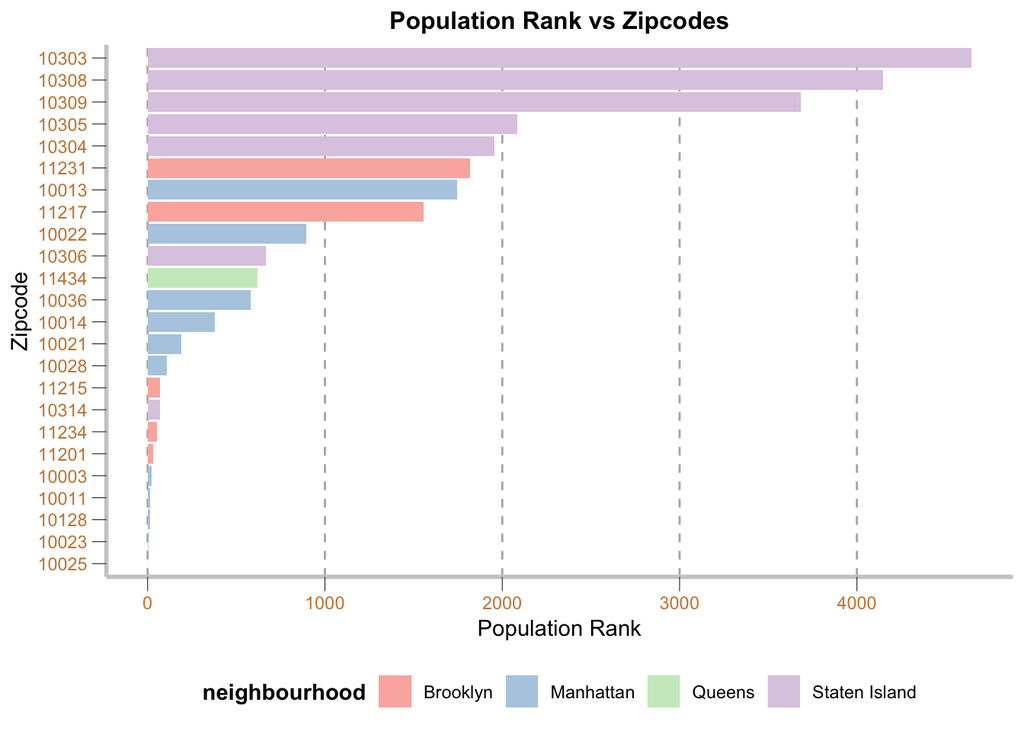

```r
data2$zipcode <-
  factor(data2$zipcode, levels = data2$zipcode[order(data2$SizeRank)])

sizerank <- data2 %>%
  ggplot(aes(x = zipcode, y = SizeRank, fill = neighbourhood)) +
  geom_histogram(stat = "identity") +
  scale_fill_brewer(palette = "Pastel1") +
  labs(title = "Population Rank vs Zipcodes", x = "Zipcode", y = "Population Rank") +
  theme(
  plot.title = element_text(size = 12, face = "bold", hjust = 0.5),
  legend.position = "bottom",
  legend.title = element_text(face = "bold"),
  panel.background = element_rect(fill = "white", colour = "white"),
  panel.grid.major = element_line(colour = "grey70", linetype = "dashed"),
  panel.grid.major.y = element_blank(),
  axis.line = element_line(size = 1, colour = "grey80"),
  axis.text = element_text(colour = "peru"),
  axis.ticks.length = unit(0.25, "cm"),
  axis.ticks = element_line(size = 0.2)
  ) +
  coord_flip()

sizerank
```

#### **Social effect**

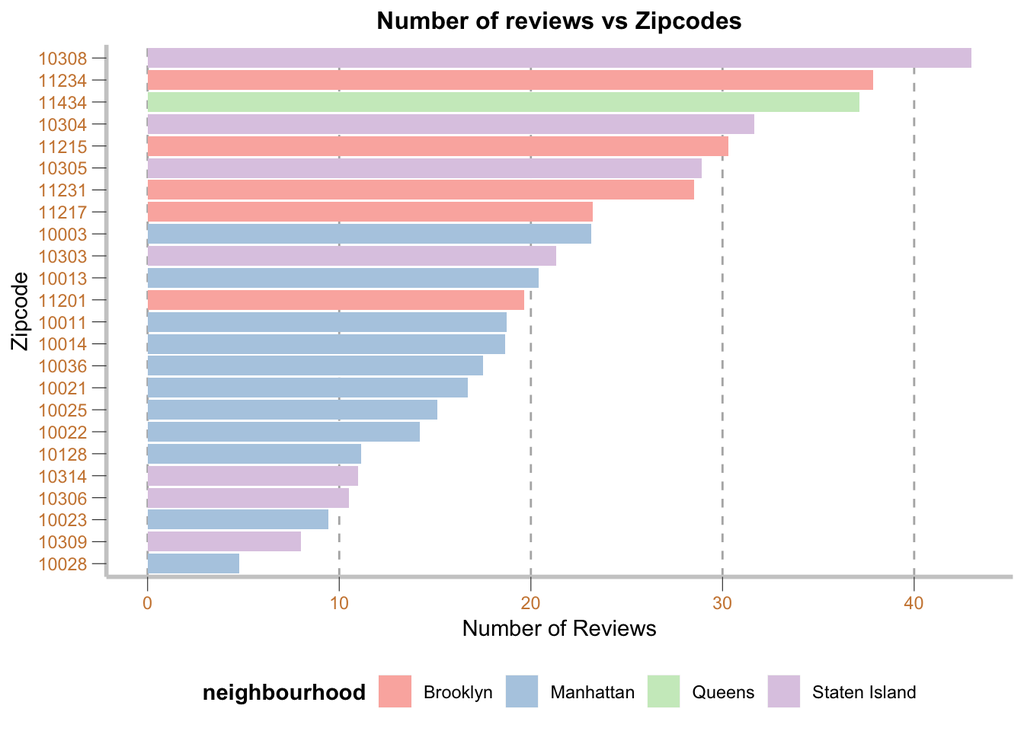

```r
data2$zipcode <-
  factor(data2$zipcode, levels = data2$zipcode[order(data2$mean_reviews)])

number_review <- data2 %>%
  ggplot(aes(x = zipcode, y = mean_reviews, fill = neighbourhood)) +
  geom_histogram(stat = "identity") +
  scale_fill_brewer(palette = "Pastel1") +
  labs(title = "Number of reviews vs Zipcodes", x = "Zipcode", y = "Number of Reviews") +
  theme(
  plot.title = element_text(size = 12, face = "bold", hjust = 0.5),
  legend.position = "bottom",
  legend.title = element_text(face = "bold"),
  panel.background = element_rect(fill = "white", colour = "white"),
  panel.grid.major = element_line(colour = "grey70", linetype = "dashed"),
  panel.grid.major.y = element_blank(),
  axis.line = element_line(size = 1, colour = "grey80"),
  axis.text = element_text(colour = "peru"),
  axis.ticks.length = unit(0.25, "cm"),
  axis.ticks = element_line(size = 0.2)
  ) +
  coord_flip()

number_review
```

==================================================================================================================

### **Analysis and Conclusion**

**Summary:**

1. Although Queens and Staten Island have highest return ratios and shortest breakeven periods, the volume of potential customers(travelers) is much less than that of Manhattan and Brooklyn.
2. Although Manhattan has highest cost in properties, and much higher break-even period than other places but there are still some place worth to invest. The price of real estate is more likely to increase and higher populations density means large potential market.

**Recommendation:**

I would recommend place with zipcode of 10025, 10036 in Manhattan and 11234 in Brooklyn. The portfolio with investment in different types of area can spread investment risks. The other reason is as follows:

**Population scale**: 10025 has a top population size rank compared to other zipcodes and 11234 in Brooklyn also has a great rank of population, while 10036 has a middle size of population, which is not bad to see a market potential.

**Return on investment**: Opposite to break-even period, zipcode 10025 and 10036 have the highest annual return rate of over 2% in Manhattan and 11234 has the top annual return rate in Brooklyn of over 4%.

**Cash liquity**: Zipcode 10025 and 10036 are almost the cheapest region in Mahattan and they get a high annual revenue. 11234 in Brooklyn also take a cheap cost to buy. 11234 has a top population rank and thus we expect the rent prices in the area would increase in the future. With a appropriate cost to buy the property, the company could better control the budget on this investment with good revenue every year.

```r
data_recom <- subset(data, data$zipcode %in% c(10025, 10036, 11234))
myPopup <- paste(sep='<br/>',
                 paste('<b>Zipcode</b>:', data_recom$zipcode),
                 paste('<b>Neighborhood</b>:', data_recom$neighbourhood_group_cleansed),
                 paste('<b>Rent price</b>:', data_recom$price),
                 paste('<b>Purchase price</b>:', format(round(data_recom$purchase_price, 2), nsmall = 2)),
                 paste('<b>Population</b>:', data_recom$SizeRank))


leaflet(width = 900, height = 500) %>% addTiles() %>% addMarkers(
  data = data_recom,
  lng = ~ longitude,
  lat = ~ latitude,
  popup = myPopup ,
  icon = list(iconUrl = 'http://icons.iconarchive.com/icons/graphicloads/colorful-long-shadow/256/Home-icon.png', iconSize = c(20, 20))
  )
```

[interactive chart not shown]

==================================================================================================================

### **Future Work**

**In the future, we need to do the following:**

**1.Get more variables and data**

Make a research to determine the occupancy rate, other revenue streams, cost components at these zip codes.

**2.Make good use of data**

Build regression model to determine which variables in Airbnb are correlated with the rent. Even apply text mining method to explore how comments and facilities influence the rent.  
Conduct time series model to explore seasonal pattern and historical trend of purchasing price and make a forecasting.

**3.Think about business and environment**

How macroeconomic factors, policies influence the investment.  
Combine the marketing strategy and target customers of the real estate company.

==================================================================================================================